# Prevalence of Lyme Disease in the US

May 13, 2015

## What is Lyme Disease?

- Infectious disease caused by the bacteria *Borrelia burgdorferi*
  - gram-negative (inner and outer membrane)
  - spirochaete
  - outer surface proteins play large role in transmission
- Ticks transmit bacteria by biting and feeding on humans

[figure not shown]

*Ixodes scapularis*  
[image](http://en.wikipedia.org/wiki/Lyme_disease)

[figure not shown]

[image](http://www.amazon.com/GIANTmicrobes-Disease-Borrelia-Burgdorferi-Microbe/dp/B000NO9HK2)

[figure not shown]

[image](http://extralymey.com/en/lyme-disease/facts-of-lyme/)

## Signs and Symptoms

- Tell-tale sign is bulls-eye rash
- **Early symptoms**
  - Fever
  - Severe fatigue
  - Chills
  - Joint and muscle aches
  - Swollen lymph nodes
- **Late symptoms**
  - Facial palsy
  - Painful and swollen large joints
  - Shooting Pains
  - Heart palpitations
  - Arthritis

[figure not shown]

[image](http://www.wbur.org/npr/165115733/reinfection-with-lyme-disease-may-cause-chronic-symptoms)

## Life Cycle of the Tick

[figure not shown]

[image](http://www.nature.com/nrmicro/journal/v10/n2/pdf/nrmicro2714.pdf)

- Risk of human infection highest in late spring and summer

## Ticks

- Locate their hosts by percieving CO[2], body heat, odors, and vibrations
- Wait on the flora, ready to make contact with the host
- Only some species of *Ixodes* (genus of hard-bodied ticks) can transmit the bacteria
- Discharge anesthetic saliva when biting
- Protein in saliva has shown to be immunosuppressive
- Must be attached for > 24 hours for risk of infection

[figure not shown]

[image](http://knowbefore.weatherbug.com/2013/07/12/the-terror-behind-the-bite-lyme-disease/)

## Project Goals and Data Used

- **Goals**
  - Interative map of Lyme disease occurrence in the US over time using the Shiny package
  - Map showing the relative population density as a measure of ruralness
  - Map showing relative percent of the population under 18 years old
- **Data**
  - CDC file containing counts of confirmed Lyme disease cases [Link to Data](http://www.cdc.gov/lyme/resources/ldpublicuse.csv)
  - 2010 census data from [Social Explorer](http://www.socialexplorer.com/)
  - US county coordinates [Shapefiles](https://www.census.gov/geo/maps-data/data/cbf/cbf_counties.html)

## Results

## Data Tidying and Calculations

- CDC Data was…
  - "tidyed" to ensure year range was a variable
  - altered so that FIPS codes matched census
  - merged with census data
  - merged with geocoordinate data
- Prevalance was…
  - calculated as the number of confirmed cases in given time frame divided by the total state or county population
  - log10 transformed before plotting to better visualize relative differences

## US County Level Maps

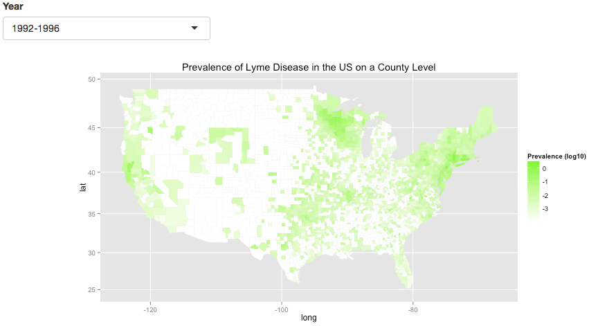

[figure not shown]

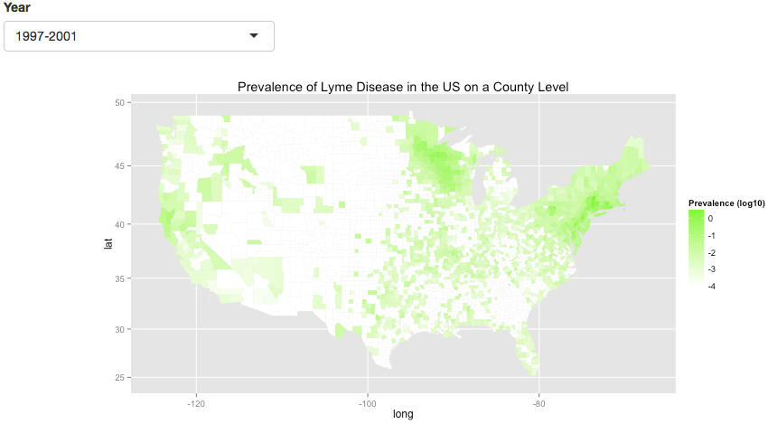

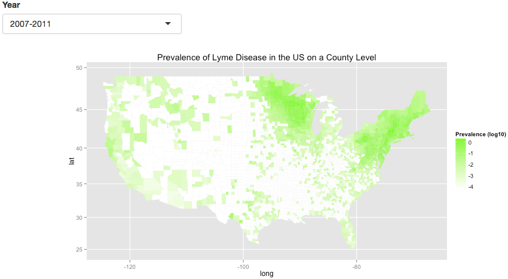

## Map of Population Density

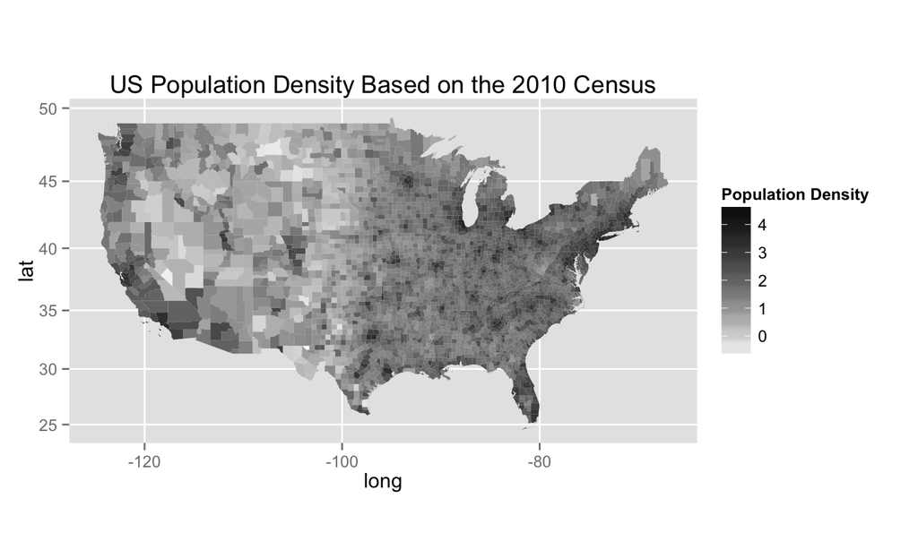

## Map of Percent of Population Under 18

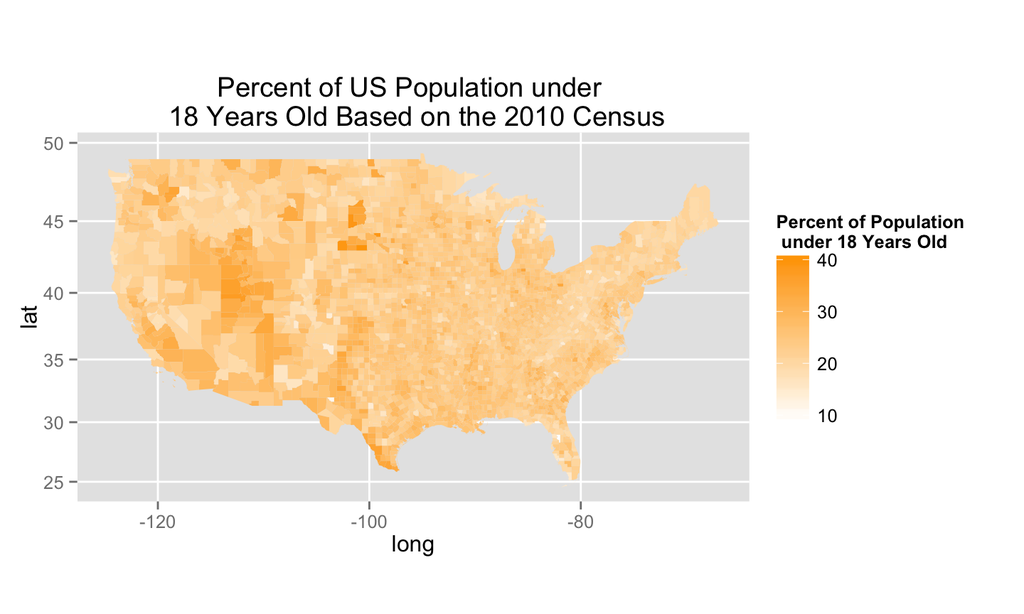

## Counties with Highest Lyme Disease Prevalence

Top Counties with Highest Prevalence of Lyme Disease

| State | County | Prevalence | year.range | LogPrevalence |
| --- | --- | --- | --- | --- |
| New York | Columbia County | 4.824395 | 2002-2006 | 0.6834428 |
| New York | Columbia County | 3.193546 | 1997-2001 | 0.5042732 |
| Massachusetts | Nantucket County | 2.959103 | 1997-2001 | 0.4711601 |
| Massachusetts | Nantucket County | 2.693669 | 1992-1996 | 0.4303442 |
| New York | Dutchess County | 2.153700 | 2002-2006 | 0.3331853 |
| New Jersey | Hunterdon County | 2.084161 | 1997-2001 | 0.3189313 |

## Importance

- Range of Lyme disease increasing due in part to reforested lands
- Important to know how Lyme disease is changing geographically
- Awareness and prevention efforts should be focused in areas that are experiencing increases in cases or lack knowlege of the disease

## References

http://www.cdc.gov/ticks/life_cycle_and_hosts.html http://www.cdc.gov/lyme/transmission/index.html http://www.cdc.gov/lyme/signs_symptoms/index.html https://microbewiki.kenyon.edu/index.php/Borrelia_burgdorferi http://www.nature.com/nrmicro/journal/v10/n2/pdf/nrmicro2714.pdf http://www.ncbi.nlm.nih.gov/pmc/articles/PMC2238774/

## Questions

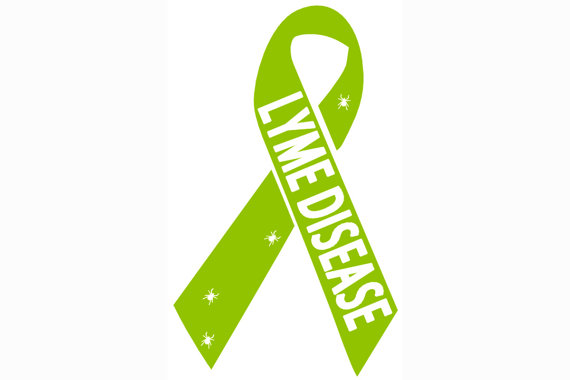